# College Proximity and Returns to Schooling : Design and Descriptive Evidence

Sample construction · treatment uptake · IV building blocks · overlap and balance

Alexander Unger

30 July 2026

**Purpose.** This notebook documents the analysis sample and the empirical features that matter for the IV design before the main estimators are compared. It reports treatment uptake, conventional IV building blocks, fitted instrument propensities, and unadjusted covariate balance. Estimator-specific weight diagnostics remain in the main analysis notebook.

# 1. Sample Construction and Data Quality

The analysis sample retains observations with non-missing wage and education.

```r
data.frame(
  Stage = c("Raw file", "Drop missing wage / educ", "Analysis sample"),
  N     = c(nrow(card_raw),
            nrow(card_raw) - nrow(card),
            nrow(card)),
  check.names = FALSE
) %>%
  kbl(caption = "Sample construction", align = c("l","r")) %>%
  kable_styling(bootstrap_options = c("striped","hover","condensed"),
                full_width = FALSE, font_size = 14) %>%
  row_spec(3, bold = TRUE)
```

Sample construction

| Stage | N |
| --- | --- |
| Raw file | 3010 |
| Drop missing wage / educ | 0 |
| Analysis sample | 3010 |

```r
miss_tab <- data.frame(
  Variable    = names(card_raw),
  Class       = vapply(card_raw, function(x) class(x)[1], character(1)),
  n_missing   = vapply(card_raw, function(x) sum(is.na(x)), integer(1)),
  pct_missing = round(100 * vapply(card_raw, function(x) mean(is.na(x)), numeric(1)), 2),
  n_unique    = vapply(card_raw, function(x) length(unique(x)), integer(1)),
  row.names   = NULL
)
miss_tab <- miss_tab[order(-miss_tab$n_missing), ]

miss_tab %>%
  kbl(caption = "Variable inventory and missingness (raw file, sorted by missing count)",
      col.names = c("Variable","Class","# missing","% missing","# unique"),
      align = c("l","l","r","r","r"), row.names = FALSE) %>%
  kable_styling(bootstrap_options = c("striped","hover","condensed"),
                full_width = TRUE, font_size = 12.5) %>%
  row_spec(which(miss_tab$n_missing > 0), background = "#fdeaea") %>%
  scroll_box(height = "360px") %>%
  footnote(general = "Highlighted rows have at least one missing value. After the wage/educ restriction the analysis sample is used everywhere below.")
```

Variable inventory and missingness (raw file, sorted by missing count)

| Variable | Class | # missing | % missing | # unique |
| --- | --- | --- | --- | --- |
| iq | numeric | 949 | 31.53 | 93 |
| fatheduc | numeric | 690 | 22.92 | 20 |
| motheduc | numeric | 353 | 11.73 | 20 |
| kww | numeric | 47 | 1.56 | 51 |
| libcrd14 | numeric | 13 | 0.43 | 3 |
| married | numeric | 7 | 0.23 | 7 |
| id | numeric | 0 | 0.00 | 3010 |
| nearc2 | numeric | 0 | 0.00 | 2 |
| nearc4 | numeric | 0 | 0.00 | 2 |
| educ | numeric | 0 | 0.00 | 18 |
| age | numeric | 0 | 0.00 | 11 |
| weight | numeric | 0 | 0.00 | 348 |
| momdad14 | numeric | 0 | 0.00 | 2 |
| sinmom14 | numeric | 0 | 0.00 | 2 |
| step14 | numeric | 0 | 0.00 | 2 |
| reg661 | numeric | 0 | 0.00 | 2 |
| reg662 | numeric | 0 | 0.00 | 2 |
| reg663 | numeric | 0 | 0.00 | 2 |
| reg664 | numeric | 0 | 0.00 | 2 |
| reg665 | numeric | 0 | 0.00 | 2 |
| reg666 | numeric | 0 | 0.00 | 2 |
| reg667 | numeric | 0 | 0.00 | 2 |
| reg668 | numeric | 0 | 0.00 | 2 |
| reg669 | numeric | 0 | 0.00 | 2 |
| south66 | numeric | 0 | 0.00 | 2 |
| black | numeric | 0 | 0.00 | 2 |
| smsa | numeric | 0 | 0.00 | 2 |
| south | numeric | 0 | 0.00 | 2 |
| smsa66 | numeric | 0 | 0.00 | 2 |
| wage | numeric | 0 | 0.00 | 755 |
| enroll | numeric | 0 | 0.00 | 2 |
| exper | numeric | 0 | 0.00 | 24 |
| lwage | numeric | 0 | 0.00 | 755 |
| expersq | numeric | 0 | 0.00 | 24 |

Note:  
Highlighted rows have at least one missing value. After the wage/educ restriction the analysis sample is used everywhere below.

# 2. Distributions of Z, D, and Y

**Instrument:** proximity to a four-year college (`nearc4`). **Treatments:** any college (`somecol`) and at least 16 years of education (`educ16`). **Outcome:** log hourly wage in dollars, matching the working outcome in the main Card notebook.

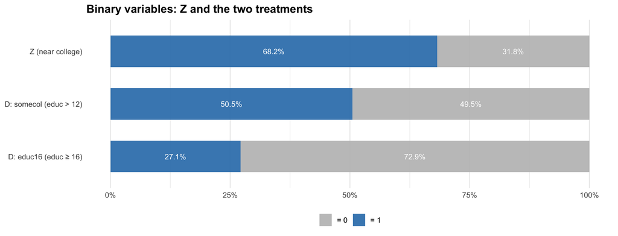

```r
bin_df <- bind_rows(
  data.frame(Variable = "Z (near college)", value = card$Z),
  data.frame(Variable = "D: somecol (educ > 12)", value = card$somecol),
  data.frame(Variable = "D: educ16 (educ ≥ 16)", value = card$educ16)
) %>%
  group_by(Variable) %>%
  summarise(`= 1` = mean(value), `= 0` = 1 - mean(value), .groups = "drop") %>%
  pivot_longer(c(`= 1`, `= 0`), names_to = "level", values_to = "share")

ggplot(bin_df, aes(x = Variable, y = share, fill = level)) +
  geom_col(width = 0.6, alpha = 0.9) +
  geom_text(aes(label = sprintf("%.1f%%", 100 * share)),
            position = position_stack(vjust = 0.5), size = 3.4, colour = "white") +
  scale_fill_manual(values = c("= 1" = col_z1, "= 0" = "#bdbdbd")) +
  scale_y_continuous(labels = percent_format(accuracy = 1)) +
  coord_flip() +
  labs(title = "Binary variables: Z and the two treatments", x = NULL, y = NULL, fill = NULL) +
  theme_minimal(base_size = 12) +
  theme(legend.position = "bottom", panel.grid.major.y = element_blank(),
        plot.title = element_text(face = "bold"))
```

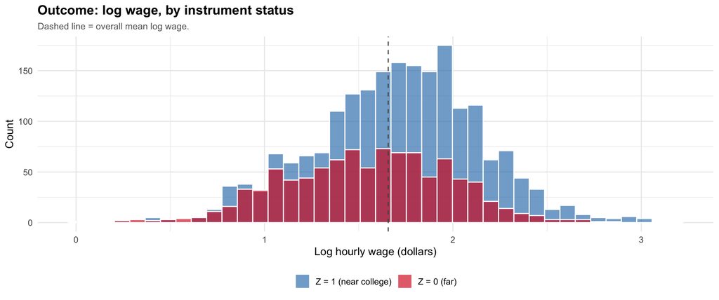

```r
card %>%
  mutate(Zlab = factor(ifelse(Z == 1, "Z = 1 (near college)", "Z = 0 (far)"),
                       levels = c("Z = 1 (near college)", "Z = 0 (far)"))) %>%
  ggplot(aes(x = lwage, fill = Zlab)) +
  geom_histogram(bins = 40, alpha = 0.65, colour = "white", position = "identity") +
  geom_vline(xintercept = mean(card$lwage), linetype = "dashed", colour = col_grey) +
  scale_fill_manual(values = c("Z = 1 (near college)" = col_z1, "Z = 0 (far)" = col_z0)) +
  labs(title = "Outcome: log wage, by instrument status",
       subtitle = "Dashed line = overall mean log wage.",
       x = "Log hourly wage (dollars)", y = "Count", fill = NULL) +
  theme_minimal(base_size = 12) +
  theme(legend.position = "bottom", plot.title = element_text(face = "bold"),
        plot.subtitle = element_text(colour = "grey40", size = 10))
```

```r
data.frame(
  Group = c("All", "Z = 1 (near)", "Z = 0 (far)"),
  N     = c(nrow(card), sum(card$Z == 1), sum(card$Z == 0)),
  Mean  = c(mean(card$lwage), mean(card$lwage[card$Z==1]), mean(card$lwage[card$Z==0])),
  SD    = c(sd(card$lwage),   sd(card$lwage[card$Z==1]),   sd(card$lwage[card$Z==0])),
  Min   = c(min(card$lwage),  min(card$lwage[card$Z==1]),  min(card$lwage[card$Z==0])),
  Max   = c(max(card$lwage),  max(card$lwage[card$Z==1]),  max(card$lwage[card$Z==0]))
) %>%
  mutate(across(c(Mean,SD,Min,Max), ~round(., 3))) %>%
  kbl(caption = "Log hourly wage summary by instrument status", align = c("l","r","r","r","r","r")) %>%
  kable_styling(bootstrap_options = c("striped","hover","condensed"),
                full_width = FALSE, font_size = 13)
```

Log hourly wage summary by instrument status

| Group | N | Mean | SD | Min | Max |
| --- | --- | --- | --- | --- | --- |
| All | 3010 | 1.657 | 0.444 | 0 | 3.18 |
| Z = 1 (near) | 2053 | 1.706 | 0.440 | 0 | 3.18 |
| Z = 0 (far) | 957 | 1.550 | 0.433 | 0 | 2.87 |

# 3. Instrument–Treatment Composition

The table reports unconditional treatment rates by instrument status. Because the Card design is analysed conditional on covariates, they are presented here as descriptive contrasts rather than direct estimates of principal-strata shares.

```r
compliance_block <- function(D, treat_name) {
  tab <- table(Z = card$Z, D = D)
  p_d_z1 <- mean(D[card$Z == 1])
  p_d_z0 <- mean(D[card$Z == 0])
  data.frame(
    Treatment       = treat_name,
    `n(Z=0,D=0)`    = tab["0","0"], `n(Z=0,D=1)` = tab["0","1"],
    `n(Z=1,D=0)`    = tab["1","0"], `n(Z=1,D=1)` = tab["1","1"],
    `Pr(D=1|Z=1)`   = round(p_d_z1, 3),
    `Pr(D=1|Z=0)`   = round(p_d_z0, 3),
    `Unadjusted gap`       = round(p_d_z1 - p_d_z0, 3),
    `Treatment rate, Z=0` = round(p_d_z0, 3),
    `Non-treatment, Z=1`  = round(1 - p_d_z1, 3),
    check.names = FALSE
  )
}

rbind(
  compliance_block(card$somecol, "somecol (educ > 12)"),
  compliance_block(card$educ16,  "educ16 (educ ≥ 16)")
) %>%
  kbl(caption = "Instrument–treatment cells and unconditional treatment-rate contrasts",
      align = c("l", rep("r", 9))) %>%
  kable_styling(bootstrap_options = c("striped","hover","condensed"),
                full_width = TRUE, font_size = 12.5) %>%
  add_header_above(c(" " = 1, "Cell counts" = 4, "Conditional treatment rates" = 2,
                     "Descriptive contrasts" = 3)) %>%
  column_spec(9, bold = TRUE, color = "#2c7bb6") %>%
  footnote(general = "The unadjusted gap is Pr(D=1|Z=1) − Pr(D=1|Z=0). A principal-strata interpretation additionally requires the relevant unconditional IV assumptions.")
```

Instrument–treatment cells and unconditional treatment-rate contrasts

| Treatment | Cell counts n(Z=0,D=0) | Cell counts n(Z=0,D=1) | Cell counts n(Z=1,D=0) | Cell counts n(Z=1,D=1) | Conditional treatment rates Pr(D=1\|Z=1) | Conditional treatment rates Pr(D=1\|Z=0) | Descriptive contrasts Unadjusted gap | Descriptive contrasts Treatment rate, Z=0 | Descriptive contrasts Non-treatment, Z=1 |
| --- | --- | --- | --- | --- | --- | --- | --- | --- | --- |
| somecol (educ > 12) | 553 | 404 | 936 | 1117 | 0.544 | 0.422 | 0.122 | 0.422 | 0.456 |
| educ16 (educ ≥ 16) | 742 | 215 | 1451 | 602 | 0.293 | 0.225 | 0.069 | 0.225 | 0.707 |

Note:  
The unadjusted gap is Pr(D=1|Z=1) − Pr(D=1|Z=0). A principal-strata interpretation additionally requires the relevant unconditional IV assumptions.

# 4. First Stage, Reduced Form, and Linear-IV Benchmarks

The first stage, reduced form, and their ratio provide transparent linear-IV benchmarks. For the single instrument, the reported HC1-robust statistic is the squared robust t-statistic.

```r
fs_diagnostic <- function(formula, data) {
  fit <- lm(formula, data = data)
  ct  <- coeftest(fit, vcov = vcovHC(fit, type = "HC1"))
  c(first_stage = unname(ct["Z", "Estimate"]),
    robust_se   = unname(ct["Z", "Std. Error"]),
    robust_t2   = unname((ct["Z", "Estimate"] / ct["Z", "Std. Error"])^2))
}

CARD_RHS <- "exper+expersq+black+south+smsa+smsa66+reg661+reg662+reg663+reg664+reg665+reg666+reg667+reg668"
KIT_RHS  <- "black+south+smsa+smsa66+south66"

fs_rows <- rbind(
  data.frame(Treatment="somecol", Spec="Card",
             t(fs_diagnostic(as.formula(paste("somecol ~ Z +", CARD_RHS)), card))),
  data.frame(Treatment="somecol", Spec="Kitagawa",
             t(fs_diagnostic(as.formula(paste("somecol ~ Z +", KIT_RHS)), card))),
  data.frame(Treatment="educ16", Spec="Card",
             t(fs_diagnostic(as.formula(paste("educ16 ~ Z +", CARD_RHS)), card))),
  data.frame(Treatment="educ16", Spec="Kitagawa",
             t(fs_diagnostic(as.formula(paste("educ16 ~ Z +", KIT_RHS)), card)))
)
fs_rows$first_stage <- round(fs_rows$first_stage, 4)
fs_rows$robust_se   <- round(fs_rows$robust_se, 4)
fs_rows$robust_t2   <- round(fs_rows$robust_t2, 1)

fs_rows %>%
  kbl(caption = "First-stage strength: effect of college proximity (Z) on each treatment",
      col.names = c("Treatment","Spec","First stage δ̂","Robust SE","Robust t²"),
      align = c("l","l","r","r","r")) %>%
  kable_styling(bootstrap_options = c("striped","hover","condensed"),
                full_width = TRUE, font_size = 13) %>%
  footnote(general = "Robust t² is the squared HC1 t-statistic for Z.")
```

First-stage strength: effect of college proximity (Z) on each treatment

| Treatment | Spec | First stage δ̂ | Robust SE | Robust t² |
| --- | --- | --- | --- | --- |
| somecol | Card | 0.0636 | 0.0180 | 12.5 |
| somecol | Kitagawa | 0.0653 | 0.0218 | 9.0 |
| educ16 | Card | 0.0302 | 0.0162 | 3.5 |
| educ16 | Kitagawa | 0.0379 | 0.0191 | 3.9 |

Note:  
Robust t² is the squared HC1 t-statistic for Z.

```r
# Reduced form (Z on Y) and covariate-adjusted Wald (= just-identified 2SLS).
rf_coef <- function(rhs) {
  fit <- lm(as.formula(paste("lwage ~ Z +", rhs)), data = card)
  ct  <- coeftest(fit, vcov = vcovHC(fit, type = "HC1"))
  unname(ct["Z","Estimate"])
}
fs_coef <- function(D, rhs) {
  v <- fs_diagnostic(as.formula(paste(D, "~ Z +", rhs)), card)
  unname(v["first_stage"])
}

wald_block <- function(Dname, treat, spec, rhs) {
  fs  <- fs_coef(Dname, rhs)
  rf  <- rf_coef(rhs)
  data.frame(
    Treatment = treat, Spec = spec,
    `First stage δ̂` = round(fs, 4),
    `Reduced form γ̂` = round(rf, 4),
    `Wald = γ̂/δ̂ (adj.)` = round(rf / fs, 4),
    check.names = FALSE
  )
}

rbind(
  wald_block("somecol", "somecol", "Card",     CARD_RHS),
  wald_block("somecol", "somecol", "Kitagawa", KIT_RHS),
  wald_block("educ16",  "educ16",  "Card",     CARD_RHS),
  wald_block("educ16",  "educ16",  "Kitagawa", KIT_RHS)
) %>%
  kbl(caption = "Linear-IV building blocks (Y = log hourly wage in dollars)",
      align = c("l","l","r","r","r")) %>%
  kable_styling(bootstrap_options = c("striped","hover","condensed"),
                full_width = TRUE, font_size = 13) %>%
  column_spec(5, bold = TRUE) %>%
  footnote(general = "With the same linear controls in both equations, the adjusted ratio equals the just-identified 2SLS coefficient.")
```

Linear-IV building blocks (Y = log hourly wage in dollars)

| Treatment | Spec | First stage δ̂ | Reduced form γ̂ | Wald = γ̂/δ̂ (adj.) |
| --- | --- | --- | --- | --- |
| somecol | Card | 0.0636 | 0.0421 | 0.6613 |
| somecol | Kitagawa | 0.0653 | 0.0375 | 0.5748 |
| educ16 | Card | 0.0302 | 0.0421 | 1.3915 |
| educ16 | Kitagawa | 0.0379 | 0.0375 | 0.9909 |

Note:  
With the same linear controls in both equations, the adjusted ratio equals the just-identified 2SLS coefficient.

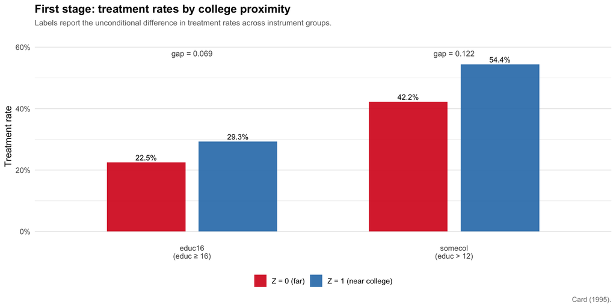

```r
fs_gap   <- card %>% summarise(z1 = mean(somecol[Z==1]), z0 = mean(somecol[Z==0]))
fs_gap_e <- card %>% summarise(z1 = mean(educ16[Z==1]),  z0 = mean(educ16[Z==0]))
gap_some <- fs_gap$z1   - fs_gap$z0
gap_educ <- fs_gap_e$z1 - fs_gap_e$z0

fs_plot_df <- data.frame(
  Treatment = factor(rep(c("somecol\n(educ > 12)", "educ16\n(educ ≥ 16)"), each = 2),
                     levels = c("educ16\n(educ ≥ 16)", "somecol\n(educ > 12)")),
  Z    = rep(c("Z = 1 (near college)", "Z = 0 (far)"), 2),
  rate = c(fs_gap$z1, fs_gap$z0, fs_gap_e$z1, fs_gap_e$z0)
)

ggplot(fs_plot_df, aes(x = Treatment, y = rate, fill = Z)) +
  geom_col(position = position_dodge(0.7), width = 0.6, alpha = 0.9) +
  geom_text(aes(label = sprintf("%.1f%%", 100*rate)),
            position = position_dodge(0.7), vjust = -0.4, size = 3.4) +
  annotate("text", x = 1, y = 0.58, label = sprintf("gap = %.3f", gap_educ),
           size = 3.5, colour = col_grey) +
  annotate("text", x = 2, y = 0.58, label = sprintf("gap = %.3f", gap_some),
           size = 3.5, colour = col_grey) +
  scale_fill_manual(values = c("Z = 1 (near college)" = col_z1, "Z = 0 (far)" = col_z0)) +
  scale_y_continuous(labels = percent_format(accuracy = 1), limits = c(0, 0.62)) +
  labs(title = "First stage: treatment rates by college proximity",
       subtitle = "Labels report the unconditional difference in treatment rates across instrument groups.",
       x = NULL, y = "Treatment rate", fill = NULL, caption = "Card (1995).") +
  theme_minimal(base_size = 12) +
  theme(legend.position = "bottom", panel.grid.major.x = element_blank(),
        plot.title = element_text(face = "bold"),
        plot.subtitle = element_text(colour = "grey40", size = 10),
        plot.caption = element_text(colour = "grey50", size = 9))
```

# 5. Propensity Score: Concentration & Overlap

The propensity score is p(X) = Pr(Z = 1 | X), fitted with the same `logit_mle` implementation used by the analysis code. Because kappa weights contain inverse-propensity terms, fitted values near zero or one can contribute to unstable weights.

## Summary Statistics

```r
ps_summary <- function(p, z, name) {
  data.frame(Specification = name,
             Min = min(p), P05 = quantile(p,0.05), P25 = quantile(p,0.25),
             Mean = mean(p), P75 = quantile(p,0.75), P95 = quantile(p,0.95),
             Max = max(p), SD = sd(p),
             `Max, Z=0` = max(p[z == 0]),
             `N(Z=0, p>.90)` = sum(z == 0 & p > 0.90),
             `Min, Z=1` = min(p[z == 1]),
             `N(Z=1, p<.10)` = sum(z == 1 & p < 0.10),
             check.names = FALSE)
}
ps_tab <- bind_rows(ps_summary(card$p_card, card$Z, "Card (14 covariates)"),
                    ps_summary(card$p_kit, card$Z, "Kitagawa (5 covariates)"))
continuous_cols <- c("Min", "P05", "P25", "Mean", "P75", "P95", "Max",
                     "SD", "Max, Z=0", "Min, Z=1")
ps_tab[continuous_cols] <- lapply(ps_tab[continuous_cols], function(x) round(x, 4))

ps_tab %>%
  kbl(caption = "Propensity score p̂(X) = Pr(Z=1|X): summary by specification",
      align = c("l", rep("r", ncol(ps_tab) - 1))) %>%
  kable_styling(bootstrap_options = c("striped","hover","condensed"),
                full_width = TRUE, font_size = 12.5) %>%
  column_spec(9, bold = TRUE) %>%
  footnote(general = "The group-specific columns target the relevant inverse-propensity tails: high p̂ among Z=0 observations and low p̂ among Z=1 observations.")
```

Propensity score p̂(X) = Pr(Z=1|X): summary by specification

|  | Specification | Min | P05 | P25 | Mean | P75 | P95 | Max | SD | Max, Z=0 | N(Z=0, p>.90) | Min, Z=1 | N(Z=1, p<.10) |
| --- | --- | --- | --- | --- | --- | --- | --- | --- | --- | --- | --- | --- | --- |
| 5%…1 | Card (14 covariates) | 0.1724 | 0.2459 | 0.4376 | 0.6821 | 0.8726 | 0.9341 | 0.9517 | 0.2356 | 0.9357 | 40 | 0.1724 | 0 |
| 5%…2 | Kitagawa (5 covariates) | 0.2532 | 0.2532 | 0.4554 | 0.6821 | 0.8783 | 0.8783 | 0.9067 | 0.2280 | 0.9067 | 9 | 0.2532 | 0 |

Note:  
The group-specific columns target the relevant inverse-propensity tails: high p̂ among Z=0 observations and low p̂ among Z=1 observations.

## Distribution by Instrument Status

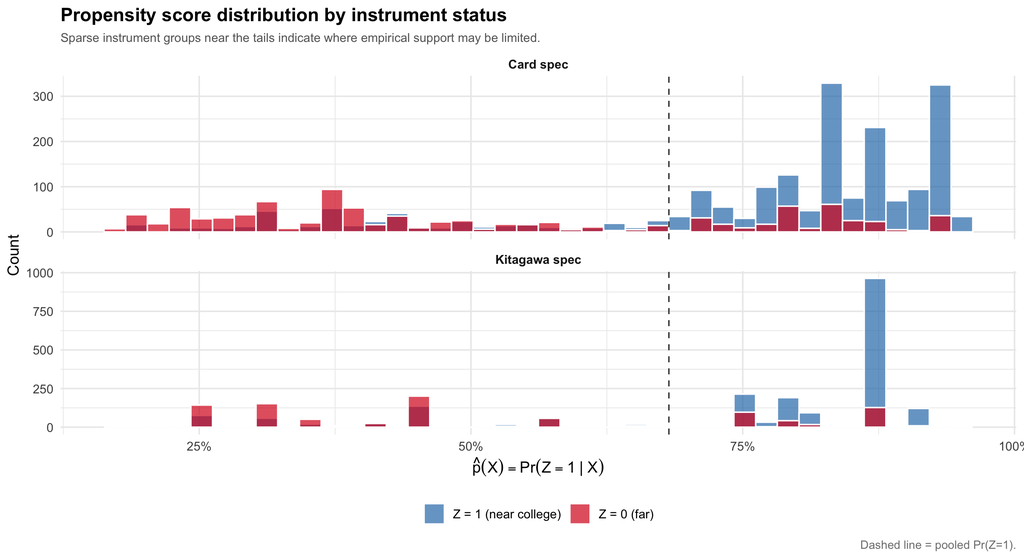

```r
ps_long <- card %>%
  select(p_card, p_kit, Z) %>%
  pivot_longer(c(p_card, p_kit), names_to = "spec", values_to = "p_hat") %>%
  mutate(Specification = factor(spec, levels = c("p_card", "p_kit"),
                                labels = c("Card spec", "Kitagawa spec")),
         Zlab = factor(ifelse(Z == 1, "Z = 1 (near college)", "Z = 0 (far)"),
                       levels = c("Z = 1 (near college)", "Z = 0 (far)")))

ggplot(ps_long, aes(x = p_hat, fill = Zlab)) +
  geom_histogram(bins = 40, alpha = 0.7, colour = "white", position = "identity") +
  geom_vline(xintercept = mean(card$Z), linetype = "dashed", colour = col_grey) +
  facet_wrap(~ Specification, ncol = 1, scales = "free_y") +
  scale_fill_manual(values = c("Z = 1 (near college)" = col_z1, "Z = 0 (far)" = col_z0)) +
  scale_x_continuous(labels = percent_format(accuracy = 1)) +
  labs(title = "Propensity score distribution by instrument status",
       subtitle = "Sparse instrument groups near the tails indicate where empirical support may be limited.",
       x = expression(hat(p)(X) == Pr(Z == 1 ~ "|" ~ X)), y = "Count", fill = NULL,
       caption = "Dashed line = pooled Pr(Z=1).") +
  theme_minimal(base_size = 12) +
  theme(legend.position = "bottom", strip.text = element_text(face = "bold"),
        plot.title = element_text(face = "bold"),
        plot.subtitle = element_text(colour = "grey40", size = 9.5),
        plot.caption = element_text(colour = "grey50", size = 9))
```